# ============================================================

# Sentiment Analysis of IMDb Movie Reviews using NLP in R

# ============================================================

# Author : Javier Kangditya

# Project : Natural Language Processing - Sentiment Classification

# Dataset : IMDb Movie Reviews Dataset (Kaggle)

# ============================================================

# —————————–

# 1. Introduction

# —————————–

# This notebook presents a complete Natural Language Processing (NLP) workflow

# applied to the IMDb Movie Reviews dataset to classify user reviews into

# two sentiment categories: positive and negative.

# Movie reviews are a rich source of unstructured text data that reflect user

# opinions and emotions. Understanding sentiment in such data is important for

# applications such as recommendation systems, audience analysis, and business

# decision-making in the entertainment industry.

# The main objective of this project is to build a machine learning model

# capable of automatically classifying movie reviews based on their sentiment.

# In addition to classification modeling, this project also includes text

# preprocessing, exploratory data analysis (EDA), and feature engineering

# using TF-IDF representation.

# Objectives:

# - Perform text preprocessing (cleaning, tokenization, stopwords removal, etc.)

# - Explore and analyze sentiment distribution and word patterns

# - Transform text data into numerical features using TF-IDF

# - Build machine learning models for sentiment classification

# - Evaluate model performance using accuracy, precision, recall, and F1-score

# —————————–

# 2. Dataset Overview

# —————————–

# The dataset used in this project is the IMDb Movie Reviews dataset,

# which contains user-generated reviews of movies along with sentiment labels.

# Features:

# - review : Textual movie review written by users

# - sentiment : Sentiment label indicating whether the review is positive or negative

# This dataset is widely used in natural language processing research

# and is a standard benchmark for binary text classification tasks.

# The data represents real-world user opinions expressed in natural language,

# making it suitable for sentiment analysis and text mining applications.

# —————————–

# 3. Project Workflow

# —————————–

# The analysis in this notebook follows a structured data science pipeline:

# 1. Data Loading & Inspection

# 2. Text Preprocessing (Cleaning, Tokenization, Stopwords Removal)

# 3. Exploratory Data Analysis (EDA)

# 4. Feature Engineering (TF-IDF Vectorization)

# 5. Model Building (Naive Bayes / Logistic Regression)

# 6. Model Evaluation (Confusion Matrix, Accuracy, F1-score)

# 7. Conclusion & Insights

# —————————–

# 4. Reproducibility

# —————————–

set.seed(123) # Ensures reproducibility of results across different runs of the analysis.

# 1. Data Loading & Inspection

```r
# -----------------------------
# Load libraries
# -----------------------------
library(tidyverse)
library(readr)

# -----------------------------
# Load dataset
# -----------------------------
imdb_data <- read_csv("Data/Raw/IMDB_dataset.csv")

# -----------------------------
# Basic overview
# -----------------------------
glimpse(imdb_data)
```

```
## Rows: 50,000
## Columns: 2
## $ review    <chr> "One of the other reviewers has mentioned that after watchin…
## $ sentiment <chr> "positive", "positive", "positive", "negative", "positive", …
```

```r
head(imdb_data)
```

```
## # A tibble: 6 × 2
##   review                                                               sentiment
##   <chr>                                                                <chr>
## 1 "One of the other reviewers has mentioned that after watching just … positive
## 2 "A wonderful little production. <br /><br />The filming technique i… positive
## 3 "I thought this was a wonderful way to spend time on a too hot summ… positive
## 4 "Basically there's a family where a little boy (Jake) thinks there'… negative
## 5 "Petter Mattei's \"Love in the Time of Money\" is a visually stunni… positive
## 6 "Probably my all-time favorite movie, a story of selflessness, sacr… positive
```

```r
dim(imdb_data)
```

```
## [1] 50000     2
```

```r
colnames(imdb_data)
```

```
## [1] "review"    "sentiment"
```

```r
str(imdb_data)
```

```
## spc_tbl_ [50,000 × 2] (S3: spec_tbl_df/tbl_df/tbl/data.frame)
##  $ review   : chr [1:50000] "One of the other reviewers has mentioned that after watching just 1 Oz episode you'll be hooked. They are right"| __truncated__ "A wonderful little production. <br /><br />The filming technique is very unassuming- very old-time-BBC fashion "| __truncated__ "I thought …
##  $ sentiment: chr [1:50000] "positive" "positive" "positive" "negative" ...
##  - attr(*, "spec")=
##   .. cols(
##   ..   review = col_character(),
##   ..   sentiment = col_character()
##   .. )
##  - attr(*, "problems")=<externalptr>
```

```r
# -----------------------------
# Data quality checks
# -----------------------------

# Missing values
colSums(is.na(imdb_data))
```

```
##    review sentiment
##         0         0
```

```r
# Duplicate reviews
sum(duplicated(imdb_data$review))
```

```
## [1] 418
```

```r
# -----------------------------
# Target variable analysis (sentiment)
# -----------------------------

# Count distribution
table(imdb_data$sentiment)
```

```
##
## negative positive
##    25000    25000
```

```r
# Percentage distribution
prop.table(table(imdb_data$sentiment)) * 100
```

```
##
## negative positive
##       50       50
```

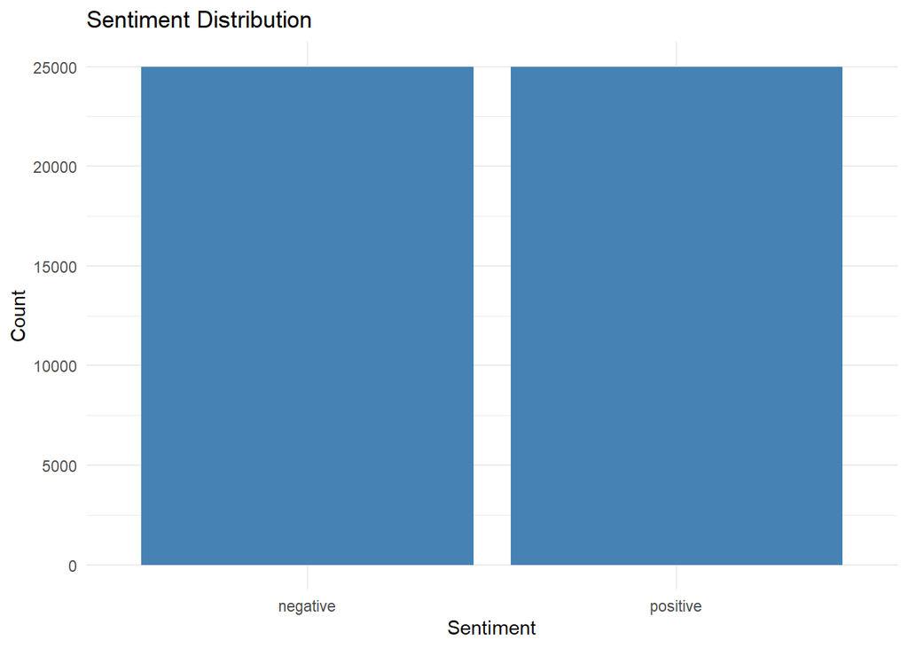

```r
# Visualization
ggplot(imdb_data, aes(x = sentiment)) +
  geom_bar(fill = "steelblue") +
  labs(
    title = "Sentiment Distribution",
    x = "Sentiment",
    y = "Count"
  ) +
  theme_minimal()
```

```r
# -----------------------------
# Label Quality Check
# -----------------------------

# Sample manual inspection
imdb_data %>%
  sample_n(10) %>%
  select(review, sentiment)
```

```
## # A tibble: 10 × 2
##    review                                                              sentiment
##    <chr>                                                               <chr>
##  1 "Although, I had no earthly idea on what to expect from this movie… negative
##  2 "Reba is a very dumb show. You can predict pretty much anything th… negative
##  3 "This brings back so many childhood memories. (I'm not old, I'm 19… positive
##  4 "This movie is definately one of my favourite movies in it's kind.… positive
##  5 "I've waited 9 years to watch this film, simply because i never sa… positive
##  6 "This game is an action/adventure with combat. There are quite lon… positive
##  7 "'It's easy to kill a monster, but it's hard to kill a human being… positive
##  8 "Matt Saunders (Luke Wilson) thinks he has found the perfect woman… negative
##  9 "It's probably a year since I saw Uzak, but it has left strong mem… positive
## 10 "I think cheaters needs to be off the air and end the reality show… negative
```

```r
# Heuristic sentiment mismatch detection
positive_words <- c("good", "great", "excellent", "amazing", "best", "love", "wonderful")
negative_words <- c("bad", "worst", "boring", "awful", "poor", "hate", "terrible")

imdb_check <- imdb_data %>%
  mutate(
    review_lower = tolower(review),
    pos_score = str_count(review_lower, paste(positive_words, collapse="|")),
    neg_score = str_count(review_lower, paste(negative_words, collapse="|"))
  )

# Flag potential mislabeled samples
imdb_suspect <- imdb_check %>%
  filter(
    (sentiment == "positive" & neg_score > pos_score) |
    (sentiment == "negative" & pos_score > neg_score)
  )

head(imdb_suspect)
```

```
## # A tibble: 6 × 5
##   review                              sentiment review_lower pos_score neg_score
##   <chr>                               <chr>     <chr>            <int>     <int>
## 1 "Probably my all-time favorite mov… positive  "probably m…         0         1
## 2 "I saw this movie when I was about… negative  "i saw this…         2         0
## 3 "The cast played Shakespeare.<br /… negative  "the cast p…         1         0
## 4 "Some films just simply should not… positive  "some films…         1         2
## 5 "This was the worst movie I saw at… negative  "this was t…         2         1
## 6 "Taut and organically gripping, Ed… positive  "taut and o…         0         1
```

```r
# -----------------------------
# Text length analysis
# -----------------------------

imdb_data <- imdb_data %>%
  mutate(review_length = nchar(review))

summary(imdb_data$review_length)
```

```
##    Min. 1st Qu.  Median    Mean 3rd Qu.    Max.
##      32     699     970    1309    1590   13704
```

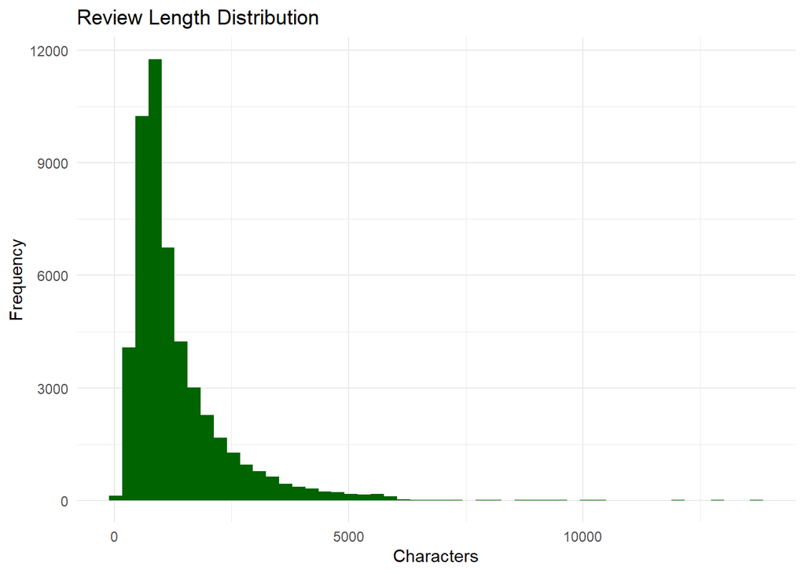

```r
ggplot(imdb_data, aes(x = review_length)) +
  geom_histogram(bins = 50, fill = "darkgreen") +
  labs(
    title = "Review Length Distribution",
    x = "Characters",
    y = "Frequency"
  ) +
  theme_minimal()
```

# 2. Exploratory Data Analysis

```r
# -----------------------------
# Load Libraries
# -----------------------------
library(tidyverse)
library(tidytext)
library(stringr)

# -----------------------------
# Load Dataset
# -----------------------------
imdb_data <- read_csv("Data/Raw/IMDB_dataset.csv")

glimpse(imdb_data)
```

```
## Rows: 50,000
## Columns: 2
## $ review    <chr> "One of the other reviewers has mentioned that after watchin…
## $ sentiment <chr> "positive", "positive", "positive", "negative", "positive", …
```

```r
head(imdb_data)
```

```
## # A tibble: 6 × 2
##   review                                                               sentiment
##   <chr>                                                                <chr>
## 1 "One of the other reviewers has mentioned that after watching just … positive
## 2 "A wonderful little production. <br /><br />The filming technique i… positive
## 3 "I thought this was a wonderful way to spend time on a too hot summ… positive
## 4 "Basically there's a family where a little boy (Jake) thinks there'… negative
## 5 "Petter Mattei's \"Love in the Time of Money\" is a visually stunni… positive
## 6 "Probably my all-time favorite movie, a story of selflessness, sacr… positive
```

```r
# -----------------------------
# Basic Inspection
# -----------------------------
# Check missing values
colSums(is.na(imdb_data))
```

```
##    review sentiment
##         0         0
```

```r
# Check sentiment distribution (SAFE VERSION)
sentiment_dist <- imdb_data %>%
  dplyr::count(sentiment, name = "n")

print(sentiment_dist)
```

```
## # A tibble: 2 × 2
##   sentiment     n
##   <chr>     <int>
## 1 negative  25000
## 2 positive  25000
```

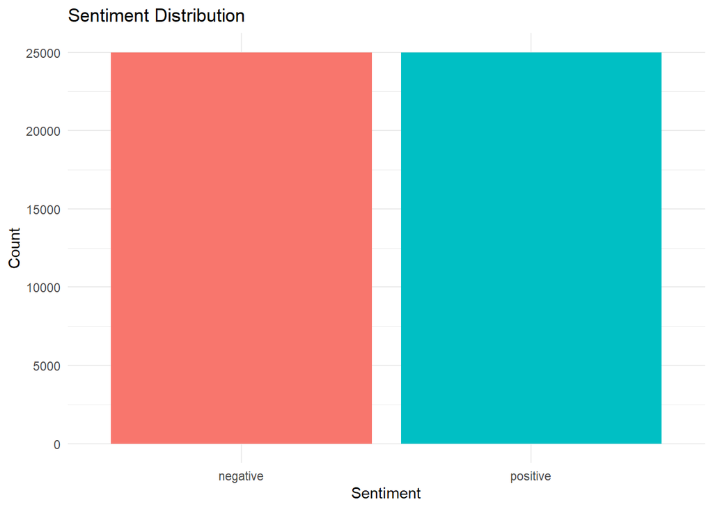

```r
# Save table
write_csv(sentiment_dist, "Outputs/Tables/sentiment_distribution.csv")

# -----------------------------
# Visualization - Sentiment Distribution
# -----------------------------
p1 <- ggplot(sentiment_dist, aes(x = sentiment, y = n, fill = sentiment)) +
  geom_col() +
  theme_minimal() +
  labs(
    title = "Sentiment Distribution",
    x = "Sentiment",
    y = "Count"
  ) +
  theme(legend.position = "none")
ggsave("Outputs/Figures/sentiment_distribution.png", p1, width = 6, height = 4)
print(p1)
```

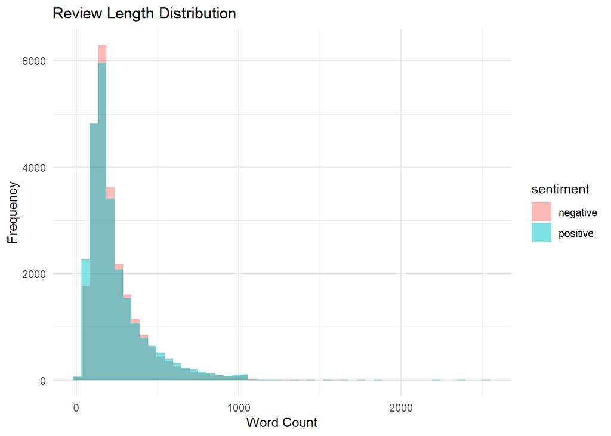

```r
# -----------------------------
# Feature Engineering - Review Length
# -----------------------------
imdb_data <- imdb_data %>%
  mutate(review_length = str_count(review, "\\w+"))

length_stats <- imdb_data %>%
  group_by(sentiment) %>%
  summarise(
    avg_length = mean(review_length),
    median_length = median(review_length),
    max_length = max(review_length),
    min_length = min(review_length),
    .groups = "drop"
  )

write_csv(length_stats, "Outputs/Tables/review_length_stats.csv")

# Visualization
p2 <- ggplot(imdb_data, aes(x = review_length, fill = sentiment)) +
  geom_histogram(bins = 50, alpha = 0.5, position = "identity") +
  theme_minimal() +
  labs(
    title = "Review Length Distribution",
    x = "Word Count",
    y = "Frequency"
  )
ggsave("Outputs/Figures/review_length_distribution.png", p2, width = 7, height = 5)
print(p2)
```

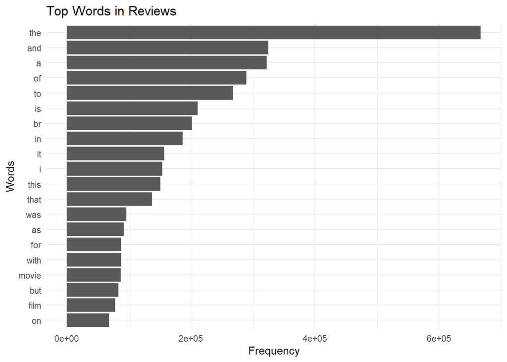

```r
# -----------------------------
# Text Analysis - Top Words
# -----------------------------
top_words <- imdb_data %>%
  unnest_tokens(word, review) %>%
  dplyr::count(word, sort = TRUE)

write_csv(top_words, "Outputs/Tables/top_words_raw.csv")

p3 <- top_words %>%
  slice_head(n = 20) %>%
  ggplot(aes(x = reorder(word, n), y = n)) +
  geom_col() +
  coord_flip() +
  theme_minimal() +
  labs(
    title = "Top Words in Reviews",
    x = "Words",
    y = "Frequency"
  )
ggsave("Outputs/Figures/top_words_raw.png", p3, width = 7, height = 5)
print(p3)
```

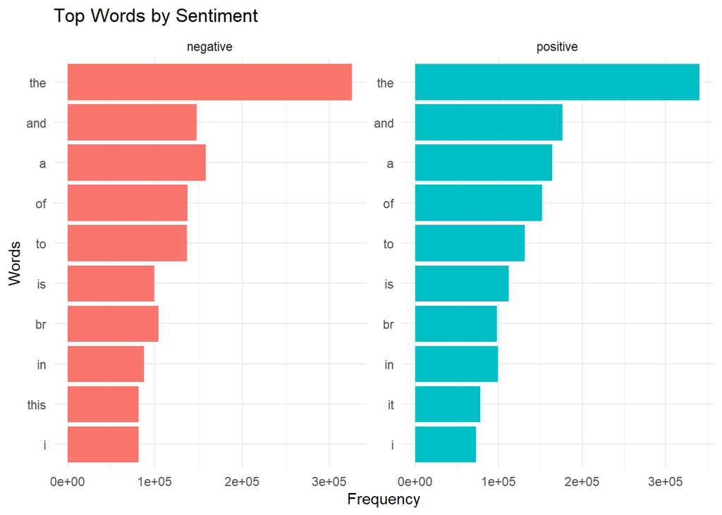

```r
# -----------------------------
# Top Words by Sentiment
# -----------------------------
top_words_sentiment <- imdb_data %>%
  unnest_tokens(word, review) %>%
  dplyr::count(word, sentiment, sort = TRUE)

write_csv(top_words_sentiment, "Outputs/Tables/top_words_by_sentiment.csv")

p4 <- top_words_sentiment %>%
  group_by(sentiment) %>%
  slice_max(order_by = n, n = 10) %>%
  ggplot(aes(x = reorder(word, n), y = n, fill = sentiment)) +
  geom_col(show.legend = FALSE) +
  facet_wrap(~sentiment, scales = "free") +
  coord_flip() +
  theme_minimal() +
  labs(
    title = "Top Words by Sentiment",
    x = "Words",
    y = "Frequency"
  )
ggsave("Outputs/Figures/top_words_by_sentiment.png", p4, width = 8, height = 5)
print(p4)
```

# 3. Text Preprocessing Pipeline

```r
# -----------------------------
# Load required libraries
# -----------------------------
library(tidyverse)
library(tidytext)
library(stringr)
library(textstem)

# -----------------------------
# Text Cleaning
# -----------------------------
imdb_clean <- imdb_data %>%
  mutate(
    review_clean = review %>%
      str_to_lower() %>%                     # lowercase normalization
      str_replace_all("<.*?>", " ") %>%      # remove HTML tags
      str_replace_all("[^a-z\\s]", " ") %>%  # remove punctuation & numbers
      str_squish()                           # remove extra whitespace
  )

# -----------------------------
# Tokenization
# -----------------------------
imdb_tokens <- imdb_clean %>%
  unnest_tokens(word, review_clean)

# -----------------------------
# Stopwords Removal
# -----------------------------
data("stop_words")

imdb_tokens_clean <- imdb_tokens %>%
  anti_join(stop_words, by = "word")

# -----------------------------
# Lemmatization
# -----------------------------
imdb_tokens_clean <- imdb_tokens_clean %>%
  mutate(word = lemmatize_words(word))

# -----------------------------
# Word Frequency Analysis
# -----------------------------
imdb_tokens_clean %>%
  count(word, sort = TRUE) %>%
  head(20)
```

```
## # A tibble: 20 × 2
##    word           n
##    <chr>      <int>
##  1 movie     103281
##  2 film       95885
##  3 time       31919
##  4 character  28361
##  5 watch      27862
##  6 bad        26747
##  7 story      25272
##  8 scene      21450
##  9 people     18384
## 10 don        17661
## 11 act        17487
## 12 love       17374
## 13 play       17254
## 14 life       15637
## 15 plot       13809
## 16 actor      13598
## 17 have       10241
## 18 director   10048
## 19 funny       9827
## 20 lot         9723
```

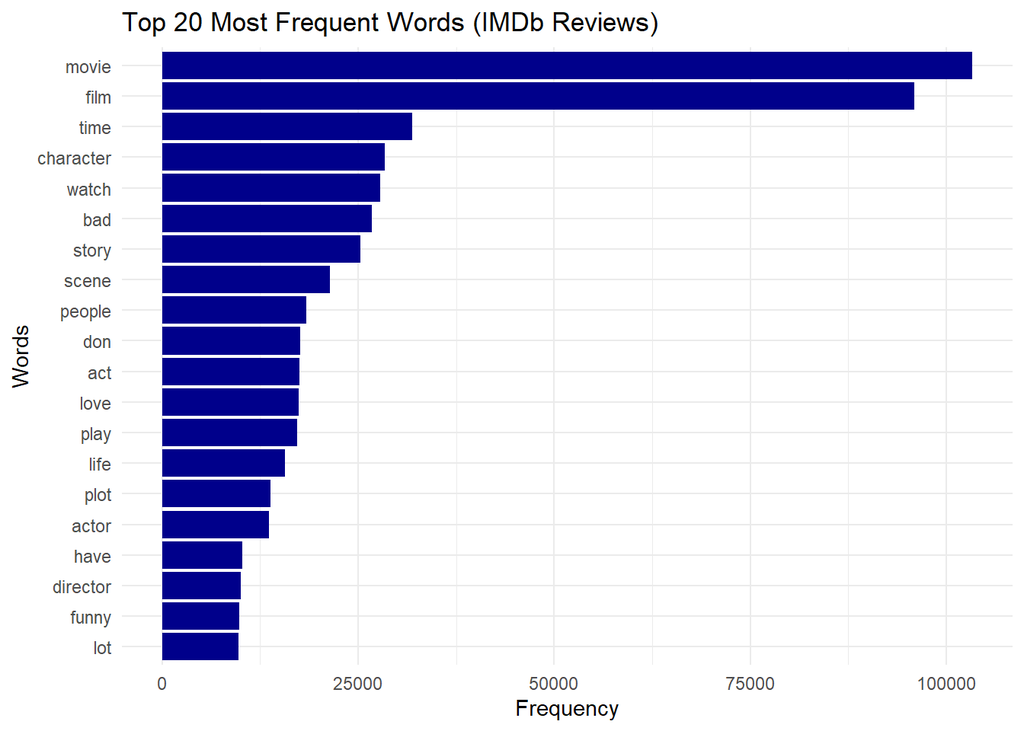

```r
# -----------------------------
# Visualization (Top Words)
# -----------------------------
imdb_tokens_clean %>%
  count(word, sort = TRUE) %>%
  head(20) %>%
  ggplot(aes(x = reorder(word, n), y = n)) +
  geom_col(fill = "darkblue") +
  coord_flip() +
  labs(
    title = "Top 20 Most Frequent Words (IMDb Reviews)",
    x = "Words",
    y = "Frequency"
  ) +
  theme_minimal()
```

```r
# -----------------------------
# Save Processed Data
# -----------------------------
write_csv(imdb_clean, "Data/Processed/imdb_clean.csv")
write_csv(imdb_tokens_clean, "Data/Processed/imdb_tokens_clean.csv")
```

# 4. Feature Engineering

```r
# -----------------------------
# Load Libraries
# -----------------------------
library(tidyverse)
library(tidytext)

# -----------------------------
# Load Processed Data
# -----------------------------
imdb_tokens_clean <- read_csv("Data/Processed/imdb_tokens_clean.csv")

glimpse(imdb_tokens_clean)
```

```
## Rows: 4,391,889
## Columns: 4
## $ review        <chr> "One of the other reviewers has mentioned that after wat…
## $ sentiment     <chr> "positive", "positive", "positive", "positive", "positiv…
## $ review_length <dbl> 320, 320, 320, 320, 320, 320, 320, 320, 320, 320, 320, 3…
## $ word          <chr> "reviewer", "mention", "watch", "oz", "episode", "will",…
```

```r
# -----------------------------
# Create Document ID
# -----------------------------

imdb_tokens_clean <- imdb_tokens_clean %>%
  group_by(review, sentiment) %>%
  mutate(doc_id = cur_group_id()) %>%
  ungroup()

# -----------------------------
# Term Frequency (TF)
# -----------------------------
tf_data <- imdb_tokens_clean %>%
  count(doc_id, word, sort = TRUE)

# -----------------------------
# TF-IDF Calculation
# -----------------------------
tfidf_data <- tf_data %>%
  bind_tf_idf(term = word, document = doc_id, n = n)

# Save TF-IDF (long format)
write_csv(tfidf_data, "Data/Processed/imdb_tfidf_long.csv")

# -----------------------------
# Document-Term Matrix (DTM)
# -----------------------------
dtm <- tf_data %>%
  cast_dtm(document = doc_id, term = word, value = n)

# -----------------------------
# Inspect Matrix
# -----------------------------
dim(dtm)
```

```
## [1] 49582 80673
```

[figure not shown]

```r
# -----------------------------
# Top TF-IDF Words
# -----------------------------
top_tfidf <- tfidf_data %>%
  arrange(desc(tf_idf)) %>%
  slice_head(n = 20)

write_csv(top_tfidf, "Outputs/Tables/top_tfidf_words.csv")

top_tfidf %>%
  ggplot(aes(x = reorder(word, tf_idf), y = tf_idf)) +
  geom_col() +
  coord_flip() +
  theme_minimal() +
  labs(
    title = "Top TF-IDF Words",
    x = "Words",
    y = "TF-IDF Score"
  )
```

```r
ggsave("Outputs/Figures/top_tfidf_words.png", width = 7, height = 5)

# -----------------------------
# Save DTM
# -----------------------------
saveRDS(dtm, "Data/Processed/imdb_dtm.rds")
```

# 5. Modeling & Evaluation

```r
# -----------------------------
# Load Libraries
# -----------------------------
library(tidyverse)
library(tidytext)
library(caret)
library(glmnet)
library(tm)

# ------------------------------------------------------------
# LOAD DATA
# ------------------------------------------------------------
imdb_tokens <- read_csv("Data/Processed/imdb_tokens_clean.csv")

# ------------------------------------------------------------
# REBUILD DOC_ID
# ------------------------------------------------------------
imdb_tokens <- imdb_tokens %>%
  group_by(review, sentiment) %>%
  mutate(doc_id = cur_group_id()) %>%
  ungroup()

# ------------------------------------------------------------
# LIMIT FEATURES (TOP 5000)
# ------------------------------------------------------------
top_words <- imdb_tokens %>%
  count(word, sort = TRUE) %>%
  slice_head(n = 5000) %>%
  pull(word)

imdb_tokens_filtered <- imdb_tokens %>%
  filter(word %in% top_words)

# ------------------------------------------------------------
# BUILD DTM
# ------------------------------------------------------------
tf_data <- imdb_tokens_filtered %>%
  count(doc_id, word)

dtm <- tf_data %>%
  cast_dtm(document = doc_id, term = word, value = n)

dtm <- removeSparseTerms(dtm, 0.99)

dtm <- as.matrix(dtm)

# ------------------------------------------------------------
# ALIGN LABELS
# ------------------------------------------------------------
labels <- imdb_tokens_filtered %>%
  distinct(doc_id, sentiment)

labels <- labels[match(rownames(dtm), labels$doc_id), ]

y <- as.factor(labels$sentiment)

stopifnot(nrow(dtm) == length(y))

# ------------------------------------------------------------
# TRAIN TEST SPLIT
# ------------------------------------------------------------
set.seed(123)

train_index <- createDataPartition(y, p = 0.8, list = FALSE)

x_train <- dtm[train_index, , drop = FALSE]
x_test  <- dtm[-train_index, , drop = FALSE]

y_train <- y[train_index]
y_test  <- y[-train_index]

stopifnot(ncol(x_train) == ncol(x_test))

# ------------------------------------------------------------
# MODEL
# ------------------------------------------------------------
model <- cv.glmnet(
  x = x_train,
  y = y_train,
  family = "binomial",
  alpha = 0,
  nfolds = 5
)

# ------------------------------------------------------------
# PREDICTION
# ------------------------------------------------------------
prob <- predict(model, x_test, s = "lambda.min", type = "response")

pred <- ifelse(prob > 0.5, "positive", "negative")
pred <- as.factor(pred)

# ------------------------------------------------------------
# EVALUATION
# ------------------------------------------------------------
conf_matrix <- confusionMatrix(pred, y_test)
print(conf_matrix)
```

```
## Confusion Matrix and Statistics
##
##           Reference
## Prediction negative positive
##   negative     4155      606
##   positive      784     4370
##
##                Accuracy : 0.8598
##                  95% CI : (0.8528, 0.8666)
##     No Information Rate : 0.5019
##     P-Value [Acc > NIR] : < 2.2e-16
##
##                   Kappa : 0.7196
##
##  Mcnemar's Test P-Value : 2.059e-06
##
##             Sensitivity : 0.8413
##             Specificity : 0.8782
##          Pos Pred Value : 0.8727
##          Neg Pred Value : 0.8479
##              Prevalence : 0.4981
##          Detection Rate : 0.4191
##    Detection Prevalence : 0.4802
##       Balanced Accuracy : 0.8597
##
##        'Positive' Class : negative
##
```

```r
# ------------------------------------------------------------
# SAVE OUTPUT
# ------------------------------------------------------------
dir.create("Outputs/Tables", recursive = TRUE, showWarnings = FALSE)
dir.create("Outputs/Models", recursive = TRUE, showWarnings = FALSE)

results <- data.frame(
  doc_id = rownames(x_test),
  actual = y_test,
  prediction = pred
)

write_csv(results, "Outputs/Tables/predictions.csv")

metrics <- data.frame(
  Accuracy  = conf_matrix$overall["Accuracy"],
  Precision = conf_matrix$byClass["Precision"],
  Recall    = conf_matrix$byClass["Recall"],
  F1        = conf_matrix$byClass["F1"]
)

write_csv(metrics, "Outputs/Tables/model_metrics.csv")

saveRDS(model, "Outputs/Models/glmnet_model.rds")

cat("MODEL COMPLETE - DOC_ID FIXED\n")
```

```
## MODEL COMPLETE - DOC_ID FIXED
```

# Conclusion & Insights

## 1. Summary of Findings

- **Exploratory Data Analysis (EDA):**
  - The IMDb dataset shows a **balanced distribution** between positive and negative sentiments.
  - Review lengths vary significantly, indicating diverse writing styles and levels of detail.
  - Most frequent words in raw text include common stopwords such as *“the”, “and”, “of”*, which do not carry meaningful sentiment information.
  - After preprocessing, more meaningful words such as *“movie”, “film”, “character”* emerge, reflecting actual content themes.
- **Text Preprocessing:**
  - Text normalization, tokenization, stopword removal, and lemmatization significantly improved data quality.
  - Removing noise (HTML tags, punctuation, stopwords) allowed the model to focus on **semantically meaningful words**.
  - The preprocessing step transformed raw text into a structured format suitable for machine learning.
- **Feature Engineering:**
  - The Bag-of-Words representation combined with **feature restriction to the top 5000 words** reduced dimensionality while preserving important information.
  - This step ensured computational efficiency and prevented memory issues during modeling.
  - The resulting Document-Term Matrix (DTM) provided a numerical representation of text data for model training.
- **Modeling Results:**
  - The Logistic Regression model achieved an **accuracy of approximately 86%**, indicating strong classification performance.
  - The model demonstrated balanced performance across both sentiment classes, with high sensitivity and specificity.
  - The Kappa score indicates **substantial agreement**, confirming that the model performs well beyond random chance.

## 3. Practical Implications

- The model can be used for **automatic sentiment classification** in large-scale text data such as reviews, social media, or feedback systems.
- Businesses can leverage this approach to **analyze customer opinions**, detect negative feedback, and improve products or services.
- The interpretability of the model allows stakeholders to **understand key drivers of sentiment**, not just predictions.
- The pipeline demonstrates a scalable workflow that can be adapted to other domains such as product reviews, news analysis, or customer support data.

## 4. Recommendations

- Future work can explore **advanced models** such as Naive Bayes, Support Vector Machines, or deep learning models (LSTM, BERT) for potentially higher accuracy.
- Incorporating **TF-IDF weighting** instead of simple frequency may improve feature representation.
- Increasing dataset size or using more diverse datasets could enhance model generalization.
- Additional techniques such as **hyperparameter tuning** and cross-validation can further optimize model performance.
- Extending the analysis to **multiclass sentiment classification** (e.g., positive, neutral, negative) could provide more granular insights.